# R Notebook to reproduce outputs displayed in Compounding hazards increase flood economic losses across Europe

# 1. Load inputs and set environment

- Source function file: `functions_CFRisks.R`
- Load NUTS region shapefiles
- Load compounding hazards datasets from previous scripts

```r
source("D:/tilloal/Documents/01_Projects/RiskDynamics/CFRisk_codes/functions_CFRisks.R")
#Set data directory
hydroDir<-("D:/tilloal/Documents/01_Projects/RiskDynamics/CFRisks_data/")

NUTS3 <- read_sf(dsn = paste0(hydroDir,"/NUTS3/NUTS3_modified.shp"))
GNUTS3sf=fortify(NUTS3)
#Load old and new NUTS3 region IDs
NUTS3_2010 <- read_sf(dsn = paste0(hydroDir,"/NUTS3/Regions_v2010_simplified.shp"))
NUTS3_2021 <- read_sf(dsn = paste0(hydroDir,"/NUTS3/Regions_v2021_simplified.shp"))

####load HANZE event set to do a first matching####
Hanze_flood=read.csv(file=paste0(hydroDir,"HANZE/HANZE_events.csv"))


#Matching of flood events with associated hazards
Hanze_flood_1980=Hanze_flood[which(Hanze_flood$Year>1980),]
Hanze_flood_1980=Hanze_flood_1980[-which(Hanze_flood_1980$Type=="Coastal"),]

#Vector of affected regions for each event
list_of_word_vectors <- lapply(Hanze_flood_1980$Regions.affected..v2021., function(x) unlist(strsplit(x, ";")))
vectors_2021=unlist(list_of_word_vectors)
vectors_2021=unique(vectors_2021)
list_of_word_vectors2 <- lapply(Hanze_flood_1980$Regions.affected..v2010., function(x) unlist(strsplit(x, ";")))
vectors_2010=unlist(list_of_word_vectors2)
vectors_2010=unique(vectors_2010)
N1021=cbind(vectors_2010,vectors_2021)

#Plot parameters
palet2=c(hcl.colors(9, palette = "Blues", alpha = NULL, rev = TRUE, fixup = TRUE))
outletname="efas_rnet_100km_01min"
outll=outletopen(hydroDir,outletname)
cord.dec=outll[,c(2,3)]
cord.dec = SpatialPoints(cord.dec, proj4string=CRS("+proj=longlat"))
cord.UTM <- spTransform(cord.dec, CRS("+init=epsg:3035"))
nco=cord.UTM@coords
world <- ne_countries(scale = "medium", returnclass = "sf")
Europe <- world[which(world$continent == "Europe"),]
e2=st_transform(Europe,  crs=3035)
w2=st_transform(world,  crs=3035)
tsize=14
osize=12
Impdates=seq(1950,2020,by=10)
valuenames=paste0("Y",Impdates)
basemap=w2

#Load compounding hazards data
fl_events=read.csv(file=paste0(hydroDir,"/hazard_data/fl_nuts3_v1.csv"))
fl_events$enddate=as.POSIXct(fl_events$enddate)
fl_events$stardate=fl_events$enddate-(fl_events$duration*3600*24)

dr_events=read.csv(file=paste0(hydroDir,"/hazard_data/dr_nuts3_v1.csv"))
dr_events$stardate=as.Date(dr_events$stardate, format="%d/%m/%Y")
dr_events$enddate=as.Date(dr_events$enddate, format="%d/%m/%Y")
dr_events<-dr_events[which(dr_events$cluster_length>=10),]

hw_events=read.csv(file=paste0(hydroDir,"/hazard_data/hw_nuts3_v1.csv"))
hw_events$stardate=as.Date(hw_events$stardate, format="%d/%m/%Y")
hw_events$enddate=as.Date(hw_events$enddate, format="%d/%m/%Y")

cw_events=read.csv(file=paste0(hydroDir,"/hazard_data/cw_nuts3_v1.csv"))
cw_events$stardate=as.Date(cw_events$stardate, format="%d/%m/%Y")
cw_events$enddate=as.Date(cw_events$enddate, format="%d/%m/%Y")

ws_events=read.csv(file=paste0(hydroDir,"/hazard_data/wgust_nuts3_995.csv"))
ws_events$stardate=as.Date(ws_events$stardate, format="%d/%m/%Y")
ws_events$enddate=as.Date(ws_events$enddate, format="%d/%m/%Y")
ws_events=ws_events[-which(ws_events$duration<1),]
ws_events=ws_events[,-5]

NutVector=NUTS3$NUTS_ID
```

# 2. Detection of optimal window for flood detection with HERA high flows

```r
initF=T
if (initF==T){
  HitF=c()
  list_POTFl_large<-list()
  llpot=c()
  llev=c()
  for (w in 0:15){
    wflood=c(w)
    df_POTFlood_large=c()
    Hanze_flood_M1=c()
    for (id in 1:length(NutVector)){
      NUTl=NutVector[id]
      High_events=fl_events[which(fl_events$NUT==NUTl),]
      if (length(High_events$X)>0){
        High_events=fl_events[which(fl_events$NUT==NUTl),]
        matches <- lapply(list_of_word_vectors, function(vector) NUTl %in% vector)
        tm=which(matches==T)
        Hanze_Nut=Hanze_flood_1980[tm,]
        #Hanze_Nut=Hanze_Nut[which(Hanze_Nut$Year>1980),]
        if(length(Hanze_Nut$Country.code)>0){
          Hanze_bNut=data.frame(NUTl,Hanze_Nut)
          Hanze_flood_M1=rbind(Hanze_flood_M1,Hanze_bNut)
        }
        #now check overlap with mt detected anomalies
        df_POTFlood_keep=c()
        Hanze_Nut$eid=Hanze_Nut$ï..ID
        for (e in 1:length(Hanze_Nut$ï..ID)){
          POTh_keep <- process_events(events_df=High_events,
                                      reference_df=Hanze_Nut ,
                                      event_idx=e, window=wflood,
                                      nut_id=NUTl,haz="flmatch")

          df_POTFlood_keep=rbind(df_POTFlood_keep,POTh_keep)
        }
        df_POTFlood_keep=as.data.frame(df_POTFlood_keep)
        df_POTFlood_large=rbind(df_POTFlood_large,df_POTFlood_keep)

      }
    }

    Hanze_flood_M1$NEID=paste0(Hanze_flood_M1$ï..ID,Hanze_flood_M1$NUTl)

    Hanze_DfNUT=aggregate(list(time=df_POTFlood_large$threshold),
                           by = list(NID=df_POTFlood_large$eventID,
                                     RID=df_POTFlood_large$NUTID),
                           FUN = function(x) c(l=length(x)))

    Hanze_DfNUT$NEID=paste0(Hanze_DfNUT$NID,Hanze_DfNUT$RID)
    Hanze_DFmNut=inner_join(Hanze_DfNUT,Hanze_flood_M1,by=c("NEID"))
    lev=length(Hanze_DFmNut$NEID)
    llev=c(llev,lev)
    lpot=length(df_POTFlood_large$eventID)
    llpot=c(llpot,lpot)
    list_POTFl_large<-c(list_POTFl_large,list(df_POTFlood_large))


    #Summary of matched flood events
    Hanze_Dflood=aggregate(list(time=df_POTFlood_large$threshold),
                           by = list(NID=df_POTFlood_large$eventID),
                           FUN = function(x) c(l=length(x)))

    Hanze_DFmatch=inner_join(Hanze_Dflood,Hanze_flood_1980,by=c("NID"="ï..ID"))

    Hit_tot=(length(Hanze_DFmatch$NID)/length(Hanze_flood_1980$Country.code)*100)

    Hit_riv=(length(Hanze_DFmatch$NID[which(Hanze_DFmatch$Type=="River")])/length(Hanze_flood_1980$Country.code[which(Hanze_flood_1980$Type=="River")])*100)

    Hit_flash=(length(Hanze_DFmatch$NID[which(Hanze_DFmatch$Type=="Flash")])/length(Hanze_flood_1980$Country.code[which(Hanze_flood_1980$Type=="Flash")])*100)

    Hits=c(w,Hit_tot,Hit_riv,Hit_flash)
    HitF=rbind(HitF,Hits)

  }
}
```

```r
#open csv form python
Hdbug<-read.csv(file=paste0(hydroDir,"/matchdebbug.csv"))

idshit<-which(is.na(match(Hanze_DFmatch$NID,Hdbug$eventID)))
merd<-Hanze_DFmatch[idshit,]
```

```r
x_values=HitF[,1]
y_values=HitF[,2]

  #ratio of new detected events in NUTS over new detected POTs
  #look for the elbow in the curve that would signify that detected POT after that do not correspond to the event.
  nvar=diff(llev)/diff(llpot)
  nvar=c(nvar,0)
  #invert nvar
  nvar=1-nvar
  y_values=nvar
  optim=elbow_finder(x_values, y_values)

  # plot(nvar,type="o")
  # abline(v=optim[1])

  plot(HitF[,2],type="o",
  xlab="Lag before and after event", ylab="Hit rate (%)", ylim=c(25,100),
  main="Optimal lag time for flood event matching")
  lines(HitF[,3], col=2, type="o")
  lines(HitF[,4], col=3, type="o")
  abline(v=optim[1])
  # Add a legend
legend("bottomright",  # Position of the legend
       legend=c("All floods", "Riverine", "Flash"),  # Labels for each series
       col=c(1, 2, 3),  # Colors matching the lines
       lty=1,  # Line type (1 = solid)
       pch=1,  # Point type
       bty="n")  # No box around the legend
```

[output not shown]

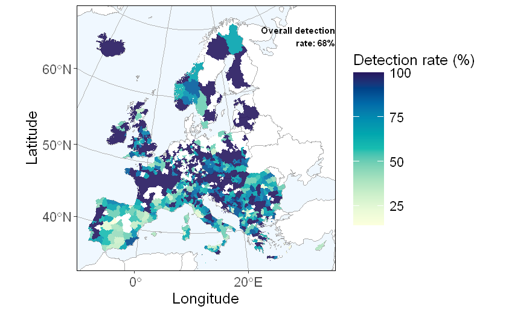

```r
w=4
wflood=c(w)
df_POTFlood_large=c()
Hanze_flood_BN=c()
list_POTFl_large=c()
for (id in 1:length(NutVector)){
  NUTl=NutVector[id]
  # NUTl="DED41"
  High_events=fl_events[which(fl_events$NUT==NUTl),]
  if (length(High_events$X)>0){
    matches <- lapply(list_of_word_vectors, function(vector) NUTl %in% vector)
    tm=which(matches==T)
    Hanze_Nut=Hanze_flood_1980[tm,]
    #Hanze_Nut=Hanze_Nut[which(Hanze_Nut$Year>1980),]
    if(length(Hanze_Nut$Country.code)>0){
      Hanze_bNut=data.frame(NUTl,Hanze_Nut)
      Hanze_flood_BN=rbind(Hanze_flood_BN,Hanze_bNut)
    }
    #now check overlap with mt detected anomalies
    df_POTFlood_keep=c()
    Hanze_Nut$eid=Hanze_Nut$ï..ID
    for (e in 1:length(Hanze_Nut$ï..ID)){
      POTh_keep <- process_events(events_df=High_events, reference_df=Hanze_Nut,
                                    event_idx=e, window=wflood, nut_id=NUTl,haz="flmatch")
      df_POTFlood_keep=rbind(df_POTFlood_keep,POTh_keep)
    }
    df_POTFlood_keep=as.data.frame(df_POTFlood_keep)
    df_POTFlood_large=rbind(df_POTFlood_large,df_POTFlood_keep)

  }
}
Hanze_flood_BN$NEID=paste0(Hanze_flood_BN$ï..ID,Hanze_flood_BN$NUTl)
list_POTFl_large<-c(list_POTFl_large,list(df_POTFlood_large))


#Summary of matched flood events
Hanze_Dflood=aggregate(list(time=df_POTFlood_large$threshold),
                       by = list(NID=df_POTFlood_large$eventID),
                       FUN = function(x) c(l=length(x)))

Hanze_DFmatch=inner_join(Hanze_Dflood,Hanze_flood_1980,by=c("NID"="ï..ID"))
Hit_tot=(length(Hanze_DFmatch$NID)/length(Hanze_flood_1980$Country.code)*100)
Hit_riv=(length(Hanze_DFmatch$NID[which(Hanze_DFmatch$Type=="River")])/length(Hanze_flood_1980$Country.code[which(Hanze_flood_1980$Type=="River")])*100)
Hit_flash=(length(Hanze_DFmatch$NID[which(Hanze_DFmatch$Type=="Flash")])/length(Hanze_flood_1980$Country.code[which(Hanze_flood_1980$Type=="Flash")])*100)
df_POTFlood=df_POTFlood_large


  #aggregate by region to have a kind of success rate spatially
  Hanze_SDflood=aggregate(list(he=df_POTFlood$threshold),
                          by = list(NUT=df_POTFlood$NUT,eid=df_POTFlood$eventID),
                          FUN = function(x) c(l=length(x)))

  Hanze_SDflood=aggregate(list(he=Hanze_SDflood$he),
                          by = list(NUT=Hanze_SDflood$NUT),
                          FUN = function(x) c(l=length(x)))

  Hanze_SOflood=aggregate(list(he=Hanze_flood_BN$Year),
                          by = list(NUT=Hanze_flood_BN$NUTl),
                          FUN = function(x) c(l=length(x)))

  Hanze_spRat=full_join(Hanze_SOflood,Hanze_SDflood,by="NUT")
  Hanze_spRat$succerat=Hanze_spRat$he.y/Hanze_spRat$he.x*100

  Hanze_spRat=inner_join(Hanze_spRat,GNUTS3sf, by=c("NUT"="NUTS_ID"))


  legend="Detection rate (%)"
  palet=c(hcl.colors(11, palette = "YlGnBu", alpha = NULL, rev = T, fixup = TRUE))
  ggplot(basemap) +
    geom_sf(fill="white",color="darkgrey",size=0.5)+
    geom_sf(data=Hanze_spRat,aes(fill=succerat,geometry=geometry),alpha=0.9,color="transparent")+
    coord_sf(xlim = c(min(nco[,1]),max(nco[,1])), ylim = c(min(nco[,2]),max(nco[,2])))+
    scale_fill_gradientn(
      colors=palet,
      oob = scales::squish,na.value="transparent", name=legend)   +
    labs(x="Longitude", y = "Latitude")+
    annotate(
    geom = "text",
    x = Inf, y = Inf, # Position text in the top right corner
    label = paste0("Overall detection\n rate: ",round(Hit_tot),"%") , # Replace with your text
    vjust = 2, hjust = 1, # Adjust vertical and horizontal justification
    size = 3, # Text size
    color = "black", # Text color
    fontface = "bold",
    family = "sans", # Font family
  )+
    theme(axis.title=element_text(size=tsize),
          title = element_text(size=osize),
          axis.text=element_text(size=osize),
          panel.background = element_rect(fill = "aliceblue", colour = "grey1"),
          panel.border = element_rect(linetype = "solid", fill = NA, colour="black"),
          legend.title = element_text(size=tsize),
          legend.text = element_text(size=osize),
          legend.position = "right",
          panel.grid.major = element_line(colour = "grey70"),
          panel.grid.minor = element_line(colour = "grey90"),
          legend.key = element_rect(fill = "transparent", colour = "transparent"),
          legend.key.size = unit(1, "cm"))
```

```r
allid=(Hanze_flood_1980$ï..ID)

mid=(unique(df_POTFlood_large$eventID))

length(which(is.na(match(allid,mid))))
```

```
[1] 430
```

```r
#load event from python
df_FloodPy<-read.csv("K:/projects/CLIMEX/CFRisks/CFRisks_data/flood_matched.csv")

df_FloodPy$NuidT<-paste0(df_FloodPy$NUT,df_FloodPy$eventID,df_FloodPy$dtime2)
df_POTFlood_large$dtime1=round(df_POTFlood_large$dtime1)
df_POTFlood_large$dtime2=round(df_POTFlood_large$dtime2)
df_POTFlood_large$NuidT<-paste0(df_POTFlood_large$NUT,                             df_POTFlood_large$eventID,df_POTFlood_large$dtime2)

mpshit=full_join(df_FloodPy,df_POTFlood_large,by=c("NuidT"))
```

# 3. Detection of compound events with different temporal windows

Four different temporal windows are tested:

- short
- medium
- large
- informed

The time window before the event is defined as follow:

| Windows | Short | Medium | Long | Informed |
| --- | --- | --- | --- | --- |
| **Days before recorded flood event starts** | 14 | 28 | 56 | Variable |

## Spatio-temporal matching for the four windows.

```r
## Definition of temporal windows ----

### Informed window----
ICW=c(14)
IHW=c(14)
IWS=c(56)
IFlood=c(56)
IDrought=c(56)

### Three tested windows----
short=c(14)
medium=c(28)
long=c(56)


windows= c("informed", "short","medium","long")

### loop over different windows ----
list_POTn_large<-list()
list_POTh_large<-list()
list_POTx_large<-list()
list_POTl_large<-list()
list_POTw_large<-list()
for (w in windows){
  if (w=="informed"){
    wflood=IFlood
    wdrought=IDrought
    wheat=IHW
    wcold=ICW
    wwind=IWS
  } else if (w=="long"){
    wflood=long
    wdrought=long
    wheat=long
    wcold=long
    wwind=long
  } else if (w=="medium"){
    wflood=medium
    wdrought=medium
    wheat=medium
    wcold=medium
    wwind=medium
  } else if (w=="short"){
    wflood=short
    wdrought=short
    wheat=short
    wcold=short
    wwind=short
  }

  df_POTn_large=c()
  df_POTx_large=c()
  df_POTh_large=c()
  df_POTl_large=c()
  df_POTw_large=c()
  for (id in 1:length(NutVector)){
    #print(id)
    #id=345
    NUTl=NutVector[id]
    #NUTl="FRK24"
    High_events=fl_events[which(fl_events$NUT==NUTl),]
    if (length(High_events$X)>0){

      Low_events=dr_events[which(dr_events$NUT==NUTl),]
      High_events=fl_events[which(fl_events$NUT==NUTl),]
      HW_events=hw_events[which(hw_events$nuts_id==NUTl),]
      CW_events=cw_events[which(cw_events$nuts_id==NUTl),]
      WS_events=ws_events[which(ws_events$nuts_id==NUTl),]
      matches <- lapply(list_of_word_vectors, function(vector) NUTl %in% vector)
      tm=which(matches==T)
      Hanze_Nut=Hanze_flood_1980[tm,]
      #Hanze_Nut=Hanze_Nut[which(Hanze_Nut$Year>1980),]
      #now check overlap with mt detected anomalies
      Hanze_Nut$eid=Hanze_Nut$ï..ID
      df_POTh_keep=c()
      df_POTl_keep=c()
      df_POTx_keep=c()
      df_POTn_keep=c()
      df_POTw_keep=c()
      for (e in 1:length(Hanze_Nut$ï..ID)){

        ### Flood sequence ----
        #modelled event has to end at minimum 4 days before observed starts
        #modelled event has to start at most xx days before observed event has started
        POTh_keep <- process_events(events_df=High_events, reference_df=Hanze_Nut,
                                    event_idx=e, window=wflood, nut_id=NUTl,haz="flood")
        df_POTh_keep=rbind(df_POTh_keep,POTh_keep)

        ### Drought-flood -----
        # #modelled event has to start before observed ends
        # #modelled event has to end at most xx days before observed event has started
        POTl_keep <- process_events(events_df=Low_events, reference_df=Hanze_Nut,
                                    event_idx=e, window=wdrought, nut_id=NUTl,haz="drought")
        df_POTl_keep=rbind(df_POTl_keep,POTl_keep)

        ### Hot-Wet sequence -----
        #modelled event has to end before observed starts
        #modelled event has to end at most xx days before observed event starts
        POTx_keep <- process_events(events_df=HW_events, reference_df=Hanze_Nut,
                                    event_idx=e, window=wheat, nut_id=NUTl,haz="heat")
        df_POTx_keep=rbind(df_POTx_keep,POTx_keep)

        ### Cold-flood event -----
        #modelled event has to start before observed ends
        #modelled event has to end at most xx days before observed event starts
        POTn_keep <- process_events(events_df=CW_events, reference_df=Hanze_Nut,
                             event_idx=e, window=wcold, nut_id=NUTl,haz="cold")
        df_POTn_keep=rbind(df_POTn_keep,POTn_keep)

        ### Wind-flood event -----
        #modelled event has to start before observed ends
        #modelled event has to end at most xx days before observed event starts
        POTw_keep <- process_events(events_df=WS_events, reference_df=Hanze_Nut,
                              event_idx=e, window=wwind, nut_id=NUTl,haz="wind")
        df_POTw_keep=rbind(df_POTw_keep,POTw_keep)
      }

      df_POTh_keep=as.data.frame(df_POTh_keep)
      df_POTl_keep=as.data.frame(df_POTl_keep)
      df_POTx_keep=as.data.frame(df_POTx_keep)
      df_POTn_keep=as.data.frame(df_POTn_keep)
      df_POTw_keep=as.data.frame(df_POTw_keep)

      df_POTh_large=rbind(df_POTh_large,df_POTh_keep)
      df_POTl_large=rbind(df_POTl_large,df_POTl_keep)
      df_POTx_large=rbind(df_POTx_large,df_POTx_keep)
      df_POTn_large=rbind(df_POTn_large,df_POTn_keep)
      df_POTw_large=rbind(df_POTw_large,df_POTw_keep)

    }
  }

  df_POTh_large$NEID=paste0(df_POTh_large$eventID,df_POTh_large$NUTID)
  df_POTl_large$NEID=paste0(df_POTl_large$eventID,df_POTl_large$NUTID)
  df_POTx_large$NEID=paste0(df_POTx_large$eventID,df_POTx_large$NUTID)
  df_POTn_large$NEID=paste0(df_POTn_large$eventID,df_POTn_large$NUTID)
  df_POTw_large$NEID=paste0(df_POTw_large$eventID,df_POTw_large$NUTID)

  list_POTn_large<-c(list_POTn_large,list(df_POTn_large))
  list_POTx_large<-c(list_POTx_large,list(df_POTx_large))
  list_POTh_large<-c(list_POTh_large,list(df_POTh_large))
  list_POTl_large<-c(list_POTl_large,list(df_POTl_large))
  list_POTw_large<-c(list_POTw_large,list(df_POTw_large))

}
```

## Analysis of the four windows and classification into all possible hazard combinations

Observed flood events can include zero (no compounding hazards) to five (all compounding hazards occur withing the defined window) compound hazards.

```r
plot1=list()
list_eventc2=list()
list_call=list()
for (w in c(1:4)){
  Events_prefflood=inner_join(list_POTh_large[[w]],Hanze_flood_1980, by=c("eventID"="ï..ID"))
  Events_precoflood=inner_join(list_POTl_large[[w]],Hanze_flood_1980, by=c("eventID"="ï..ID"))
  Events_prehflood=inner_join(list_POTx_large[[w]],Hanze_flood_1980, by=c("eventID"="ï..ID"))
  Events_precflood=inner_join(list_POTn_large[[w]],Hanze_flood_1980, by=c("eventID"="ï..ID"))
  Events_prewflood=inner_join(list_POTw_large[[w]],Hanze_flood_1980, by=c("eventID"="ï..ID"))

  Events_prehflood$time=Events_prehflood$stardate
  Events_precflood$time=Events_precflood$stardate
  Events_prewflood$time=Events_prewflood$stardate

  ### creation of table with similar structures for each hazard -----
  ##### Flood----
  C_flood_ev=Events_prefflood
  C_flood_ev$stdate=as.POSIXct(as.Date(C_flood_ev$stpeaks, origin = "1980-01-01"))

  #identification of events that correspond to the recorded flood event
  kept_col=c("NUT","dtime1", "duration","peaks","time","eventID","NEID")
  mkc=match(kept_col,colnames(C_flood_ev))
  C_flood_ev=C_flood_ev[mkc]
  C_flood_ev$peaks=(C_flood_ev$peaks-.98)/0.02
  C_flood_ev$time=as.Date(C_flood_ev$time)

  ##### Cold ----
  C_cold_ev=Events_precflood
  dura=as.numeric(difftime(as.Date(C_cold_ev$end),as.Date(C_cold_ev$begin)))
  C_cold_ev$time=as.Date(C_cold_ev$time)
  C_cold_ev$duration=C_cold_ev$intensity
  C_cold_ev$NUT=C_cold_ev$nuts_id
  C_cold_ev$peaks=1
  C_cold_ev$dtime1[which(C_cold_ev$dtime1>0)]=0
  colsel=match(colnames(C_flood_ev),colnames(C_cold_ev))
  C_cold_ev=C_cold_ev[colsel]
  ymon=month(C_cold_ev$time)
  #remove cold events occuring during the "warm season"
  season=rep("cold",length(ymon))
  season[which(ymon>4 & ymon<11)]="warm"
  C_cold_ev=C_cold_ev[-which(season=="warm"),]

  ##### Heat ----
  C_heat_ev=Events_prehflood
  dura=as.numeric(difftime(as.Date(C_heat_ev$end),as.Date(C_heat_ev$begin)))
  C_heat_ev$time=as.Date(C_heat_ev$time)
  C_heat_ev$duration=C_heat_ev$intensity
  C_heat_ev$NUT=C_heat_ev$nuts_id
  C_heat_ev$peaks=1
  colsel=match(colnames(C_flood_ev),colnames(C_heat_ev))
  C_heat_ev=C_heat_ev[colsel]
  ymon=month(C_heat_ev$time)
  #remove hot events occuring during the "cold season"
  season=rep("cold",length(ymon))
  season[which(ymon>4 & ymon<11)]="warm"
  C_heat_ev=C_heat_ev[-which(season=="cold"),]

  #### Wind ----
  C_wind_ev=Events_prewflood
  dura=as.numeric(difftime(as.Date(C_wind_ev$enddate),as.Date(C_wind_ev$stardate)))
  C_wind_ev$time=as.Date(C_wind_ev$time)
  C_wind_ev$duration=dura
  C_wind_ev$NUT=C_wind_ev$nuts_id
  C_wind_ev$peaks=C_wind_ev$intensity
  C_wind_ev$dtime1[which(C_wind_ev$dtime1>0)]=0
  colsel=match(colnames(C_flood_ev),colnames(C_wind_ev))
  C_wind_ev=C_wind_ev[colsel]

  ##### Drought ----
  C_drought_ev=Events_precoflood
  C_drought_ev$low_peaks=((1-C_drought_ev$low_peaks)-0.95)/0.05
  C_drought_ev$time=as.Date(C_drought_ev$time)
  C_drought_ev$peaks=C_drought_ev$low_peaks
  C_drought_ev$duration=C_drought_ev$cluster_length
  C_drought_ev$dtime1[which(C_drought_ev$dtime1>0)]=0
  colsel=match(colnames(C_flood_ev),colnames(C_drought_ev))
  C_drought_ev=C_drought_ev[colsel]
  names(C_drought_ev)=names(C_heat_ev)=names(C_cold_ev)=names(C_wind_ev)=names(C_flood_ev)

  C_drought_ev$evtype="drought"
  C_flood_ev$evtype="flood"
  C_heat_ev$evtype="heat"
  C_cold_ev$evtype="cold"
  C_wind_ev$evtype="wind"

  ### Combine all detected compound events ----
  C_all_haz=rbind(C_flood_ev,C_drought_ev,C_heat_ev,C_cold_ev,C_wind_ev)
  list_call<-c(list_call,list(C_all_haz))

  all_events=unique(Hanze_flood_1980$ï..ID)
  mh_events=unique(C_all_haz$eventID)

  #number of events for each category
  v1=(unique(Hanze_flood_1980$ï..ID))
  v2=(unique(Events_prefflood$eventID))
  v3=(unique(Events_precoflood$eventID))
  v4=(unique(Events_prehflood$eventID))
  v5=(unique(Events_precflood$eventID))
  v6=(unique(Events_prewflood$eventID))

  #number of single events
  s_events=all_events[which(is.na(match(all_events,mh_events)))]

  evtypes=c("drought","flood","heat","cold","wind","single")
  events_class=c()
  for (ie in 1:length(all_events))
  {
    evsel=all_events[ie]
    cls=vector(mode="integer",length=7)
    C_all_s=C_all_haz[which(C_all_haz$eventID==evsel),]
    cls[1]=evsel
    evt=unique(C_all_s$evtype)
    if (length(C_all_s$NUT)<1){
      evt="single"
    }
    mt=which(!is.na(match(evtypes,evt)))
    cls[mt+1]=1
    events_class=rbind(events_class,cls)
  }

  events_class=as.data.frame(events_class)
  events_class$nh=events_class[,2]+events_class[,3]+events_class[,4]+events_class[,5]+events_class[,6]


  colnames(events_class)=c("eventID","predrought","preflood","preheat","precold","prewind","single","nh")

  #single events category
  sing_events=events_class[which(events_class$nh==0),]
  sing_events$event_name="single-flood"

  #bivariate events category
  biv_events=events_class[which(events_class$nh==1),]
  biv_events$event_name=NA
  biv_events$event_name[which(biv_events$predrought==1)]="drought-flood"
  biv_events$event_name[which(biv_events$preflood==1)]="wet-sequence"
  biv_events$event_name[which(biv_events$preheat==1)]="heat-flood"
  biv_events$event_name[which(biv_events$precold==1)]="cold-flood"
  biv_events$event_name[which(biv_events$prewind==1)]="wind-flood"

  #trvariate events category
  triv_events=events_class[which(events_class$nh==2),]
  triv_events$event_name=NA
  triv_events$event_name[which(triv_events$predrought==1 &
                                 triv_events$preflood==1)]="drought-wet-sequence"
  triv_events$event_name[which(triv_events$predrought==1 &
                                 triv_events$preheat==1)]="heat-drought-flood"
  triv_events$event_name[which(triv_events$preflood==1 &
                                 triv_events$preheat==1)]="heat-wet-sequence"
  triv_events$event_name[which(triv_events$preflood==1 &
                                 triv_events$precold==1)]="cold-wet-sequence"
  triv_events$event_name[which(triv_events$preheat==1 &
                                 triv_events$precold==1)]="cold-heat-wet"
  triv_events$event_name[which(triv_events$predrought==1 &
                                 triv_events$precold==1)]="cold-drought-flood"
  triv_events$event_name[which(triv_events$predrought==1 &
                                 triv_events$prewind==1)]="wind-drought-flood"
  triv_events$event_name[which(triv_events$preflood==1 &
                                 triv_events$prewind==1)]="wind-wet-sequence"
  triv_events$event_name[which(triv_events$precold==1 &
                                 triv_events$prewind==1)]="wind-cold-flood"
  triv_events$event_name[which(triv_events$preheat==1 &
                                 triv_events$prewind==1)]="wind-heat-flood"
```

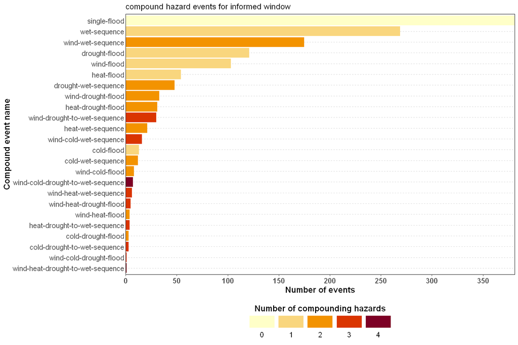

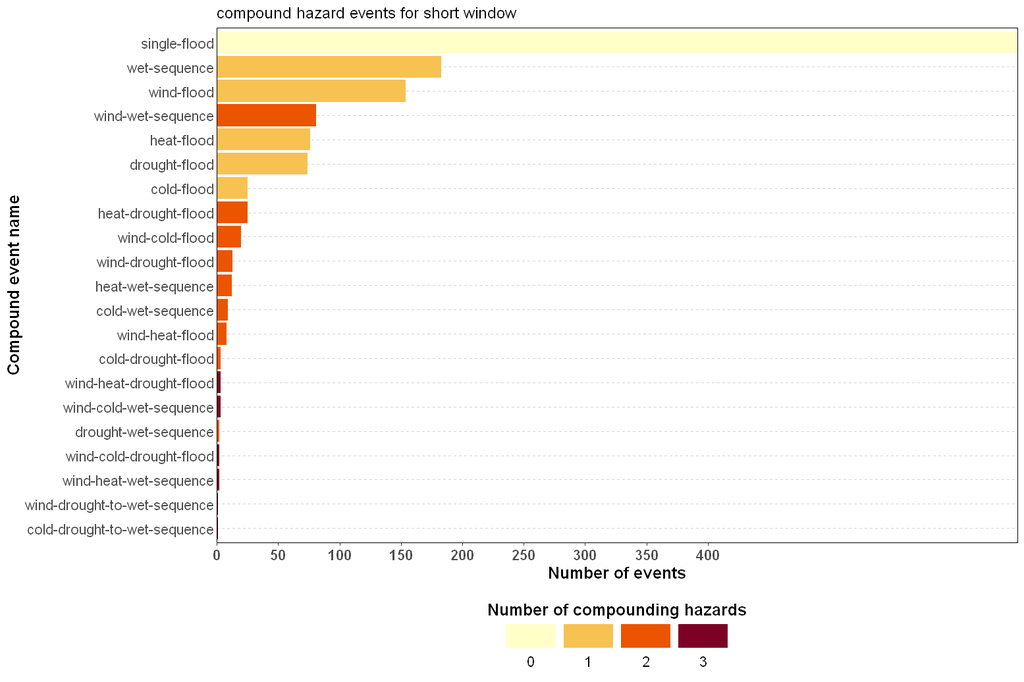

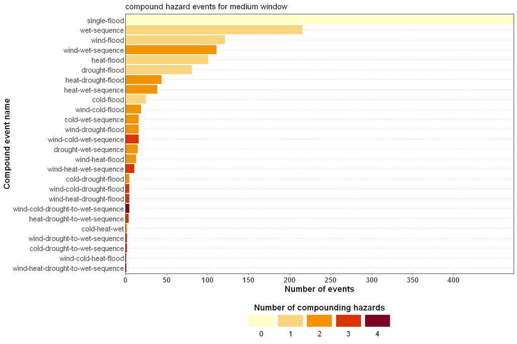

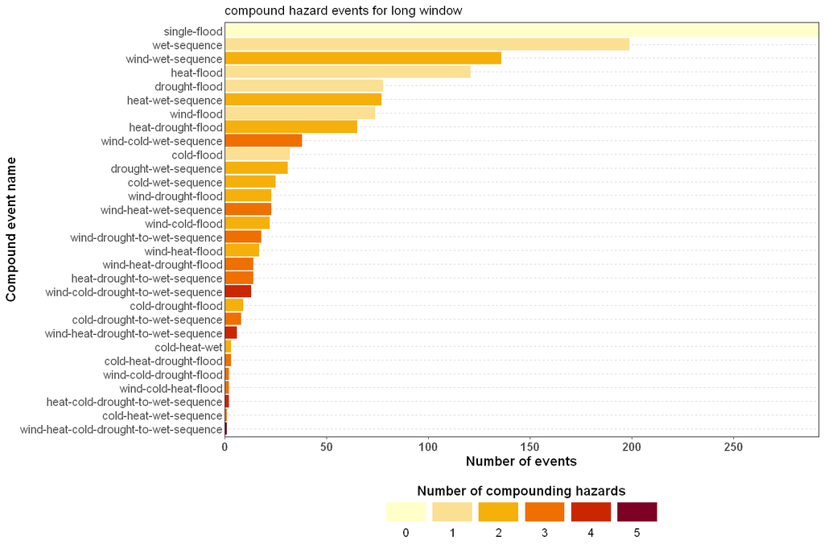

```r
  #all events together
  event_class2=rbind(sing_events,biv_events,triv_events)

  #quadrivariate events category
  quadriv_events=events_class[which(events_class$nh==3),]
  if (length(quadriv_events$eventID)>0){
    quadriv_events$event_name=NA
    quadriv_events$event_name[which(quadriv_events$predrought==1 &
                                      quadriv_events$preflood==1 &
                                      quadriv_events$preheat==1)]="heat-drought-to-wet-sequence"
    quadriv_events$event_name[which(quadriv_events$predrought==1 &
                                      quadriv_events$preflood==1 &
                                      quadriv_events$precold==1)]="cold-drought-to-wet-sequence"
    quadriv_events$event_name[which(quadriv_events$preheat==1 &
                                      quadriv_events$preflood==1 &
                                      quadriv_events$precold==1)]="cold-heat-wet-sequence"
    quadriv_events$event_name[which(quadriv_events$prewind==1 &
                                      quadriv_events$preheat==1 &
                                      quadriv_events$precold==1)]="wind-cold-heat-flood"
    quadriv_events$event_name[which(quadriv_events$predrought==1 &
                                      quadriv_events$prewind==1 &
                                      quadriv_events$precold==1)]="wind-cold-drought-flood"
    quadriv_events$event_name[which(quadriv_events$predrought==1 &
                                      quadriv_events$preheat==1 &
                                      quadriv_events$prewind==1)]="wind-heat-drought-flood"
    quadriv_events$event_name[which(quadriv_events$preflood==1 &
                                      quadriv_events$preheat==1 &
                                      quadriv_events$prewind==1)]="wind-heat-wet-sequence"
    quadriv_events$event_name[which(quadriv_events$preflood==1 &
                                      quadriv_events$precold==1 &
                                      quadriv_events$prewind==1)]="wind-cold-wet-sequence"
    quadriv_events$event_name[which(quadriv_events$preflood==1 &
                                      quadriv_events$predrought==1 &
                                      quadriv_events$prewind==1)]="wind-drought-to-wet-sequence"
    quadriv_events$event_name[which(quadriv_events$precold==1 &
                                      quadriv_events$preheat==1 &
                                      quadriv_events$predrought==1)]="cold-heat-drought-flood"
    event_class2=rbind(event_class2,quadriv_events)
  }
  #remaining events
  quindriv_events=events_class[which(events_class$nh==4),]
  if (length(quindriv_events$eventID)>0){
    quindriv_events$event_name=NA
    quindriv_events$event_name[which(quindriv_events$precold==1 &
                                       quindriv_events$predrought==1 &
                                       quindriv_events$preflood==1 &
                                       quindriv_events$preheat==1)]="heat-cold-drought-to-wet-sequence"
    quindriv_events$event_name[which(quindriv_events$precold==1 &
                                       quindriv_events$predrought==1 &
                                       quindriv_events$preflood==1 &
                                       quindriv_events$prewind==1)]="wind-cold-drought-to-wet-sequence"
    quindriv_events$event_name[which(quindriv_events$prewind==1 &
                                       quindriv_events$predrought==1 &
                                       quindriv_events$preflood==1 &
                                       quindriv_events$preheat==1)]="wind-heat-drought-to-wet-sequence"
    quindriv_events$event_name[which(quindriv_events$prewind==1 &
                                       quindriv_events$precold==1 &
                                       quindriv_events$preflood==1 &
                                       quindriv_events$preheat==1)]="wind-heat-cold-wet-sequence"
    quindriv_events$event_name[which(quindriv_events$prewind==1 &
                                       quindriv_events$predrought==1 &
                                       quindriv_events$precold==1 &
                                       quindriv_events$preheat==1)]="wind-heat-cold-drought-flood"
    event_class2=rbind(event_class2,quindriv_events)
  }

  sixdriv_events=events_class[which(events_class$nh==5),]
  if (length(sixdriv_events$eventID)>0){
    sixdriv_events$event_name=NA
    sixdriv_events$event_name="wind-heat-cold-drought-to-wet-sequence"

    event_class2=rbind(event_class2,sixdriv_events)
  }
  uni=unique(event_class2$event_name)
  event_class2$event_name <- factor(event_class2$event_name,  levels =uni)
  event_class2$nhcat=as.character(event_class2$nh)
  list_eventc2=c(list_eventc2,list(event_class2))

  ###[Supplement Plot] - plot of detected multi-hazard events before attribution to archetypes ----

  lpalett=length(unique(event_class2$nhcat))
  palet=c(hcl.colors(lpalett, palette = "YlOrRd", alpha = NULL, rev = T, fixup = TRUE))
  current_window=windows[w]
  plot1[[w]]<- ggplot(event_class2, aes(x = fct_rev(fct_infreq(event_name)),fill = nhcat))+
    geom_bar() +
    coord_flip()+
    scale_fill_manual(
      values=palet, name="Number of compounding hazards")   +
    guides(fill = guide_legend(title.position = "top",nrow = 1,
                               reverse=F, title.hjust=0.5,
                               barwidth = 3, barheight = 1.5)) +
    scale_y_continuous(name="Number of events",breaks=seq(0,400, by=50),expand = expansion(mult = c(0, 0)))+
    scale_x_discrete(name="Compound event name")+
    theme(axis.title=element_text(size=14, face="bold"),
          axis.text = element_text(size=12),
          axis.text.x = element_text(size=12,face="bold"),
          panel.background = element_rect(fill = "white", colour = "white"),
          panel.grid = element_blank(),
          panel.border = element_rect(linetype = "solid", fill = NA, colour="black"),
          legend.title = element_text(size=14, face="bold"),
          legend.text = element_text(size=12),
          axis.ticks.y = element_blank(),  # Remove x-axis tickmarks
          panel.grid.major.y = element_line(color = "lightgray",linetype="dashed"),
          panel.grid.minor.y = element_line(color = "lightgray"),
          panel.grid.major.x = element_blank(),
          legend.position = "bottom",
          legend.title.position = "top",
          legend.text.position = "bottom",
          # panel.grid.major = element_line(colour = "grey80"),
          panel.grid.minor.x = element_blank(),
          legend.key = element_rect(fill = "transparent", colour = "transparent"),
          legend.key.size = unit(.8, "cm"))+
    ggtitle(paste0("compound hazard events for ",current_window," window"))
    print(plot1[[w]])
}
```

```r
list_test<-list_eventc2[[1]]
sum(list_test$predrought)
```

```
[1] 287
```

Reorganize compound events into five compound events archetypes:

| Compound event archetype | Definition | Hazard interrelation type |
| --- | --- | --- |
| **Wet sequence** | Period of wet conditions preceding a flood impact event. | Precondition – temporally compound |
| **Drought-flood** | Flood impact event occurs during or soon after a drought. | Multivariate - Temporally compound |
| **Cold-flood** | Flood event occurs during or rapidly after a cold wave. | Precondition |
| **Heat-flood sequence** | Flood impact event occurs rapidly after a heatwave. | Precondition |
| **Compound wind-flood** | Extreme wind precedes or co-occurs with a flood impact event. | Multivariate - Temporally compound |

Recorded flood events with multiple matching compound hazards are duplicated.

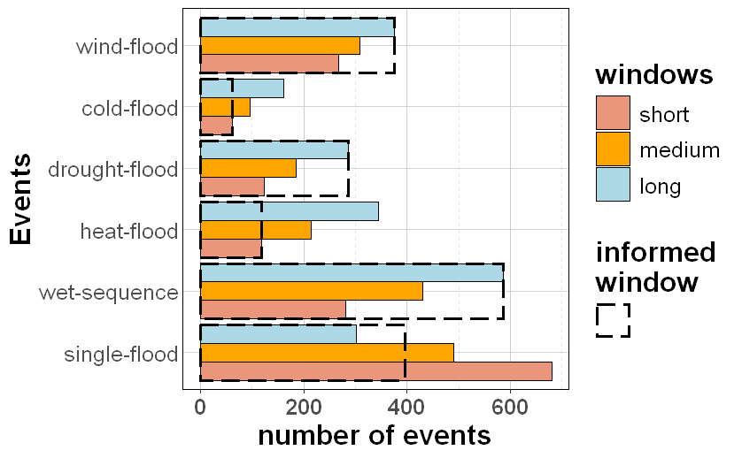

```r
col_locs=c("predrought","preflood","preheat","precold","prewind")
taglist=c()
event_classic=c()
event_multlist=c()
for (w in 1:4){
  event_all1=list_eventc2[[w]]
  aev=length(unique(event_all1$eventID))
  event_mh=event_all1[which(event_all1$nh>=2),]
  mhev=unique(event_mh$eventID)
  event_nh=event_all1[which(event_all1$nh<2),]
  # loop over event_mh
  event_m1=event_mh[1,]
  # Repeat each event (rows) nh (the number of different compounding hazards) times
  repeated_table <- event_mh[rep(1:nrow(event_mh), event_mh$nh), ]
  event_mh2=c()
  for (evi in 1:length(mhev)){
    event_m1=repeated_table[which(repeated_table$eventID==mhev[evi]),]
    hs=which(event_m1[1,]==1)
    locp=match(col_locs,colnames(event_m1))
    for(r in 1:length(hs)){
      rh=hs[r]
      locn=locp[-which(locp==rh)]
      event_m1[r,locn]=0
    }
    event_mh2=rbind(event_mh2,event_m1)
  }
  event_mh2$event_name <- as.character(event_mh2$event_name)
  event_mh2$event_name[which(event_mh2$predrought==1)]="drought-flood"
  event_mh2$event_name[which(event_mh2$preflood==1)]="wet-sequence"
  event_mh2$event_name[which(event_mh2$preheat==1)]="heat-flood"
  event_mh2$event_name[which(event_mh2$precold==1)]="cold-flood"
  event_mh2$event_name[which(event_mh2$prewind==1)]="wind-flood"

  #remerge events
  event_mh3=rbind(event_nh,event_mh2)
  event_mh3$rep=event_mh3$nh
  event_mh3$rep[which(event_mh3$nh==0)]=1
  #merge with HANZE
  event_class3=inner_join(event_mh3,Hanze_flood_1980,by=c("eventID"="ï..ID"))
  event_classic=rbind(event_classic,event_class3)

  #aggregate by event type for fatalities, people affected and economic damages
  event_tag<-aggregate(list(losses=event_class3$Losses..2020.euro.,
                            fat=event_class3$Fatalities,af=event_class3$Persons.affected,
                            nh=event_class3$rep),
                       by = list(Events=event_class3$event_name),
                       FUN = function(x) c(mean=mean(x,na.rm=T),len=length(x),sum=sum(x,na.rm=T)))
  event_tag <- do.call(data.frame, event_tag)

  event_mag<-aggregate(list(losses=event_class3$Losses..2020.euro.),
                       by = list(Events=event_class3$eventID),
                       FUN = function(x) c(len=length(x)))
  event_mag <- do.call(data.frame, event_mag)
  event_mult=sum(event_mag$losses)/length(event_mag$losses)
  event_multlist=c(event_multlist,event_mult)

  event_tag$nh=event_tag$nh.mean
  event_tag<-event_tag[,-c(11,12,13)]
  event_tag$window=windows[w]
  taglist=rbind(taglist,event_tag)
}

#color scale for events
color_events=c("single-flood"="gray","wet-sequence"="dodgerblue4","heat-flood"="darksalmon","drought-flood"="orange","cold-flood"="lightblue","wind-flood"="seagreen")

color_windows=c("short"="darksalmon","medium"="orange","long"="lightblue","physical"="darkgrey")

# reorder the levels of the window column
taglist$Events <- factor(taglist$Events,
                         levels = c("single-flood","wet-sequence","heat-flood","drought-flood","cold-flood","wind-flood"),
                         ordered = TRUE)

taglist$window <- factor(taglist$window,
                         levels =c("informed","short","medium","long"),
                         ordered = TRUE)

#check that the same amount of events are present for each window
taglist_chk<-aggregate(list(len=taglist$fat.len),
                       by = list(taglist$window),
                       FUN = function(x) c(sum=sum(x,na.rm=T)))
taglist_chk <- do.call(data.frame, taglist_chk)
taglist_chk$mult=event_multlist


taginformed=taglist[which(taglist$window=="informed"),]
taginformed$color="black"
tagother=taglist[-which(taglist$window=="informed"),]

ggplot(tagother, aes(x = Events,y=losses.len,fill=window,category=window))+
  geom_bar(stat = "identity",position="dodge",color="black")+
  geom_bar(data=taginformed, aes(x = Events,y=losses.len,color=color),
           stat = "identity",position="dodge",fill="transparent",lwd=1,lty=5)+
  scale_y_continuous(name="number of events")+
  coord_flip()+
  scale_fill_manual(
    values=color_windows,name="windows") +
  scale_color_manual(
    values="black",label="",name="informed \nwindow") +
  theme(axis.title=element_text(size=18, face="bold"),
        axis.text = element_text(size=14),
        axis.text.x = element_text(size=14,face="bold"),
        panel.background = element_rect(fill = "white", colour = "white"),
        panel.grid = element_blank(),
        panel.border = element_rect(linetype = "solid", fill = NA, colour="black"),
        legend.title = element_text(size=18, face="bold"),
        legend.text = element_text(size=14),
        axis.ticks.y = element_blank(),  # Remove x-axis tickmarks
        panel.grid.major.y = element_line(color = "lightgray"),
        panel.grid.minor.y = element_line(color = "lightgray"),
        legend.position = "right",
        panel.grid.major = element_line(colour = "grey80"),
        panel.grid.minor.x = element_line(colour = "grey90",linetype="dashed"),
        legend.key = element_rect(fill = "transparent", colour = "transparent"),
        legend.key.size = unit(.8, "cm"))
```